# Lab1 - Milestone 2

Bruno Dias - contato@diasbruno.com

March 17, 2016

## Uso das cotas parlamentares

Para esta análise, o objetivo foi encontrar os deputados que ultrapassam suas cotas parlamentares. Existe um limite mensal por deputado que é definido pela Camara dos Deputados. Pude encontrar essa informação [aqui](http://www2.camara.leg.br/comunicacao/assessoria-de-imprensa/cota-parlamentar).

O primeiro passo foi analisar qual o subconjunto do *data frame* que vou utilizar. Após ler a [documentação](http://www2.camara.leg.br/transparencia/cota-para-exercicio-da-atividade-parlamentar/explicacoes-sobre-o-formato-dos-arquivos-xml) decidi que para o que quero mostrar, preciso usar as seguintes variáveis:

- **txNomeParlamentar**: Nome adotado pelo Parlamentar ao tomar posse do seu mandato.
- **sgPartido**: O seu conteúdo representa a sigla de um partido.
- **sgUF**: No contexto da cota CEAP, representa a unidade da federação pela qual o deputado foi eleito e é utilizada para definir o valor da cota a que o deputado tem.
- **txtDescricao**: O seu conteúdo é a descrição do Tipo de Despesa relativo à despesa em questão.
- **vlrDocumento**: O seu conteúdo é o valor de face do documento fiscal ou o valor do documento que deu causa à despesa
- **vlrLiquido**: O seu conteúdo representa o valor líquido do documento fiscal ou do documento que deu causa à despesa e será calculado pela diferença entre o Valor do Documento e o Valor da Glosa.
- **numMes**: O seu conteúdo representa o Mês da competência financeira do documento fiscal ou do documento que deu causa à despesa.

### Gasto Mensal dos Parlamentares

Irei plotar um gráfico para fazer uma observação geral sobre o **gasto mensal** de cada parlamentar.

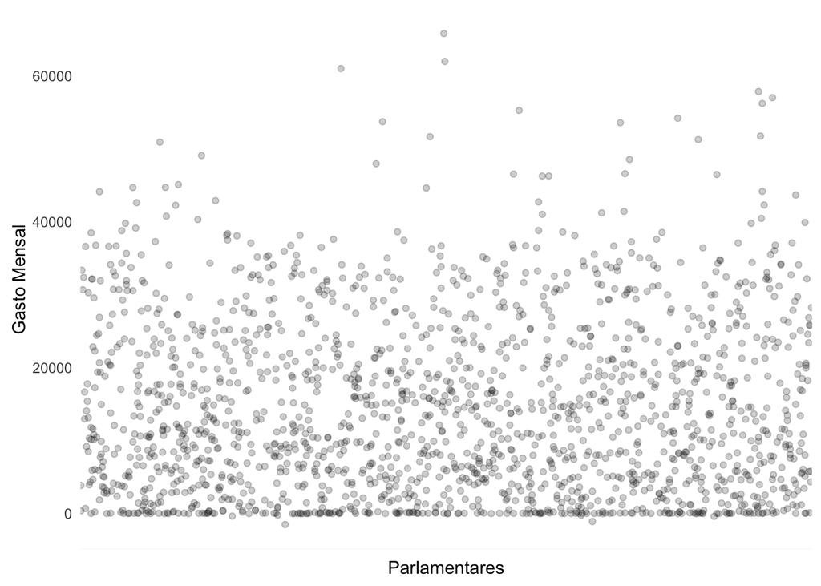

Percebi, pelo gráfico acima, que grande parte dos gastos mensais estão abaixo dos R$ 30 mil reais, que é o valor da **menor cota** dentre os estados brasileiros. No sumário gerado abaixo podemos visualizar as cotas parlamentares.

```
##    Min. 1st Qu.  Median    Mean 3rd Qu.    Max.
##   30420   38570   40500   39880   41970   45240
```

Entretanto, olhando para o sumário das cotas com calma e fazendo uma comparação com o gráfico, notei algo estranho em alguns pontos do gráfico que excedem o limite máximo de cotas dentre os estados. Dedico a próxima seção para investigar essa situação.

### Deputados da PB que ultrapassaram o limite da cota

Para fazer essa análise, tive que importar o *data frame* do limite de cotas por estado. Esse é um dos desafios encontrados nesse trabalho.

Depois de importar o data frame, fiz um gráfico para analisar se existe algum deputado do nosso estado que estourou a cota mensal. Analisando o gráfico, fica claro que 4 dos parlamentares do nosso estado excederam os limites mensais das cotas parlamentares. Isso é um dado preocupante, levando em consideração que os gastos gerais dos deputados já são altos!

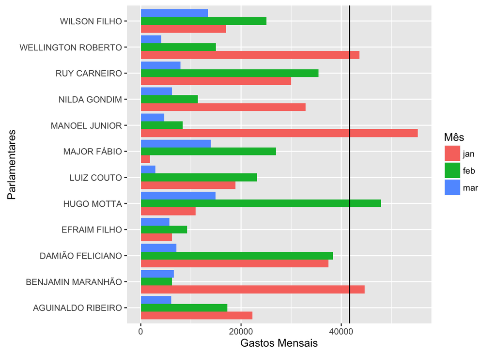

O limite da cota do estado da Paraíba é de R$ 41.660,70. No mês de Janeiro, por exemplo, 3 deputados ultrapassaram esse limite. Já que foi possível enxergar esse tipo de problema na nossa realidade loca, tento expandir essa análise pra o restante do país.

<sub>PS: O mês de abril foi ignorado, pois só existem 3 parlamentares com gasto nesse mês e o gasto é muito abaixo das cotas.</sub>

### Ranking dos parlamentares que excederam o limite da cota

Para realizar esse levantamento, tive que utilizar a função `merge` do R, que funciona semelhante ao JOIN do SQL. A função abaixo, se comporta de maneira equivalente ao OUTER JOIN feito em Banco de Dados.

O ranking mostra que por 45 vezes em **QUATRO** meses os parlamentares. Vale lembrar que essa amostragem tem pouquissímos dados do mês de abril. O mais alarmante é que alguns deputados excedem o limite em até **DOIS** meses!

```
##    sgUF  txNomeParlamentar numMes    total
## 1    PB WELLINGTON ROBERTO      1 43627.22
## 2    SP    VICENTE CANDIDO      1 56971.35
## 3    BA    VALMIR ASSUNÇÃO      1 42265.80
## 4    SE    VALADARES FILHO      1 44133.11
## 5    SE    VALADARES FILHO      2 56171.43
## 6    BA    ULDURICO JUNIOR      3 51704.58
## 7    MG   TONINHO PINHEIRO      3 57796.81
## 8    MT      SÁGUAS MORAES      2 46441.39
## 9    SC    RONALDO BENEDET      2 51224.98
## 10   GO   ROBERTO BALESTRA      1 54150.25
## 11   SP       PAULO FREIRE      2 48505.53
## 12   MG    PAULO ABI-ACKEL      2 46558.36
## 13   AL             PAULÃO      1 41396.71
## 14   PI        PAES LANDIM      1 53542.34
```

[output cut: 31 more lines]

Para visualizar melhor, coloquei uma cor diferente nos deputados que estouraram a cota no mesmo gráfico que mostrei anteriormente dos gastos mensais de todos os deputados.

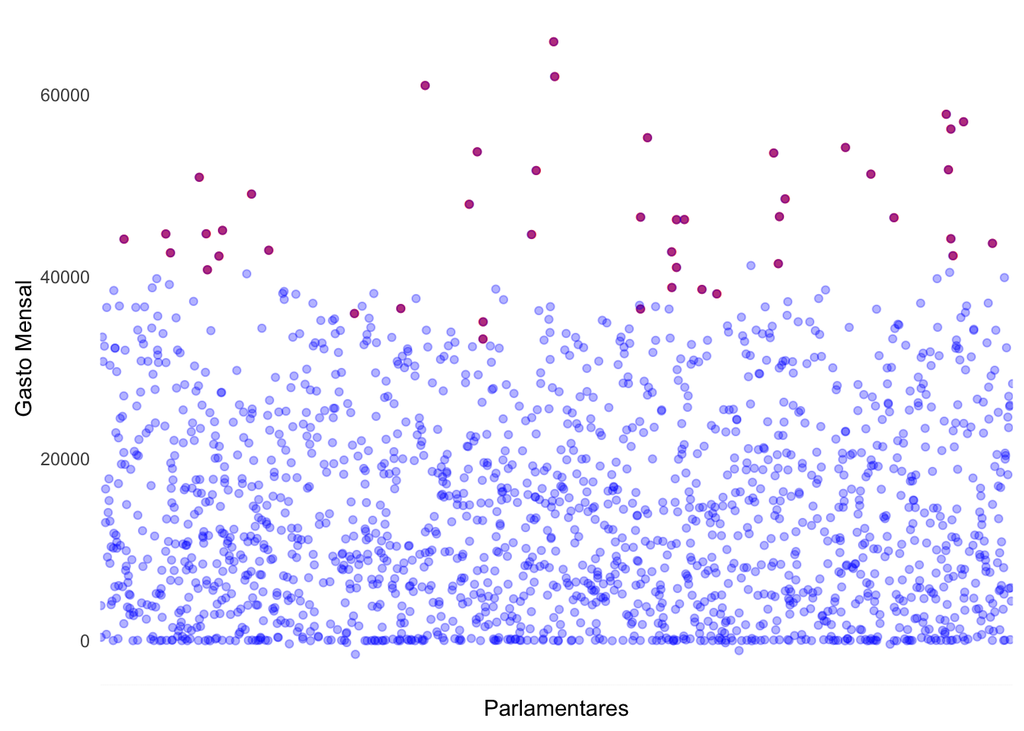

```r
ggplot(deputadosEstourados, aes(x = txNomeParlamentar, y = total)) +
  geom_point(alpha = 0.75, color="red") +
  xlab("Parlamentares") +
  ylab("Gasto Mensal") +
  theme_get() +
  theme(axis.text.x=element_blank(),
       axis.ticks=element_blank()) +
  geom_jitter(data=gastosDeputadosMensal, aes(x = txNomeParlamentar, y = total), alpha = 0.3, color ="blue")
```

Nesse momento, comprovo o que tinha achado estranho na análise inicial. Os pontos que se dispersam pra cima no nosso gráfico, são os deputados que estouraram as cotas mensais de seus estados.

Provavelmente, se conseguirmos uma amostragem do ano inteiro de 2015, iria encontrar muito mais parlamentares que excederam as cotas mensais. Isso é realmente preocupante no funcionamento do legislativo.

## Perguntas complementares

Como atividade complementar, preciso fazer um levantamento de **quais as empresas que mais prestaram serviços** para os deputados.

### Lista de empresas que mais prestaram serviços no período

Como pude perceber, dentre as 10 empresas que mais prestaram serviços para os deputados, três são companhias aéreas e três são dos correios. Essa informação sugere que a maior parte dos gastos dos parlamentares foram com viagens e trânsito de encomendas.

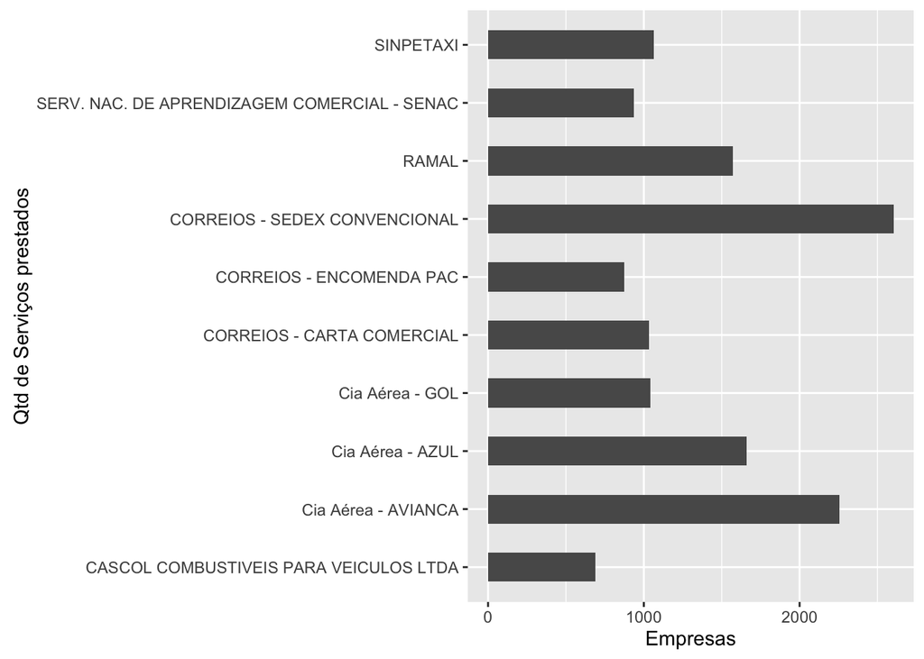

Agora vou rankear as maiores despesas que os parlamentares têm por tipo.

```
## Source: local data frame [17 x 2]
##
##                                                 txtDescricao      total
##                                                       (fctr)      (dbl)
## 1                       DIVULGAÇÃO DA ATIVIDADE PARLAMENTAR. 6144336.98
## 2  MANUTENÇÃO DE ESCRITÓRIO DE APOIO À ATIVIDADE PARLAMENTAR 3101321.72
## 3              LOCAÇÃO OU FRETAMENTO DE VEÍCULOS AUTOMOTORES 3078783.03
## 4                              COMBUSTÍVEIS E LUBRIFICANTES. 2929342.85
## 5                                      Emissão Bilhete Aéreo 2670227.43
## 6              CONSULTORIAS  PESQUISAS E TRABALHOS TÉCNICOS. 2647918.48
## 7                                                  TELEFONIA 2040214.15
## 8                                           SERVIÇOS POSTAIS  830694.71
## 9                                           PASSAGENS AÉREAS  605330.50
## 10                FORNECIMENTO DE ALIMENTAÇÃO DO PARLAMENTAR  420526.93
## 11                        LOCAÇÃO OU FRETAMENTO DE AERONAVES  359340.00
## 12    HOSPEDAGEM  EXCETO DO PARLAMENTAR NO DISTRITO FEDERAL.  301623.64
## 13  SERVIÇO DE SEGURANÇA PRESTADO POR EMPRESA ESPECIALIZADA.  231894.64
## 14                 SERVIÇO DE TÁXI  PEDÁGIO E ESTACIONAMENTO  120061.90
## 15                                 ASSINATURA DE PUBLICAÇÕES   31326.50
## 16               PASSAGENS TERRESTRES  MARÍTIMAS OU FLUVIAIS   12591.48
## 17                      LOCAÇÃO OU FRETAMENTO DE EMBARCAÇÕES    5301.81
```

Notei que **DIVULGAÇÃO DA ATIVIDADE PARLAMENTAR** (publicidade) é onde existe mais gastos pelos deputados. Mas não podemos ignorar alguns outros fatores que são um pouco estranhos. Olhando detalhadamente, consegui perceber algo estranho, existe dois tipos de despesas que parecem iguais, *Emissão Bilhete Aéreo* e *PASSAGENS AÉREAS*, percebendo isso, reorganizei o data frame para rankear novamente os gastos. Mesmo com essa reorganização o gasto com publicidade é quase o dobro comparado com o gasto com passagens aéreas.

```
## Source: local data frame [16 x 2]
##
##                                                 txtDescricao      total
##                                                       (fctr)      (dbl)
## 1                       DIVULGAÇÃO DA ATIVIDADE PARLAMENTAR. 6144336.98
## 2                                      Emissão Bilhete Aéreo 3275557.93
## 3  MANUTENÇÃO DE ESCRITÓRIO DE APOIO À ATIVIDADE PARLAMENTAR 3101321.72
## 4              LOCAÇÃO OU FRETAMENTO DE VEÍCULOS AUTOMOTORES 3078783.03
## 5                              COMBUSTÍVEIS E LUBRIFICANTES. 2929342.85
## 6              CONSULTORIAS  PESQUISAS E TRABALHOS TÉCNICOS. 2647918.48
## 7                                                  TELEFONIA 2040214.15
## 8                                           SERVIÇOS POSTAIS  830694.71
## 9                 FORNECIMENTO DE ALIMENTAÇÃO DO PARLAMENTAR  420526.93
## 10                        LOCAÇÃO OU FRETAMENTO DE AERONAVES  359340.00
## 11    HOSPEDAGEM  EXCETO DO PARLAMENTAR NO DISTRITO FEDERAL.  301623.64
## 12  SERVIÇO DE SEGURANÇA PRESTADO POR EMPRESA ESPECIALIZADA.  231894.64
## 13                 SERVIÇO DE TÁXI  PEDÁGIO E ESTACIONAMENTO  120061.90
## 14                                 ASSINATURA DE PUBLICAÇÕES   31326.50
## 15               PASSAGENS TERRESTRES  MARÍTIMAS OU FLUVIAIS   12591.48
## 16                      LOCAÇÃO OU FRETAMENTO DE EMBARCAÇÕES    5301.81
```

Apesar de ter comprovado parte da suspeita inicial, que dado a quantidade de lançamentos de passagens aéreas era possível que uma das maiores despesas financeiras dos parlamentares seriam com passagens aéreas, não foi possível perceber no gráfico inicial que os deputados gastaram cerca de 25% de todas as despesas com publicidade. Isso é um ponto interessante para entrar em detalhes, em algum momento oportuno.

```
## [1] 0.2406634
```